# Storyboard example

[figure not shown]

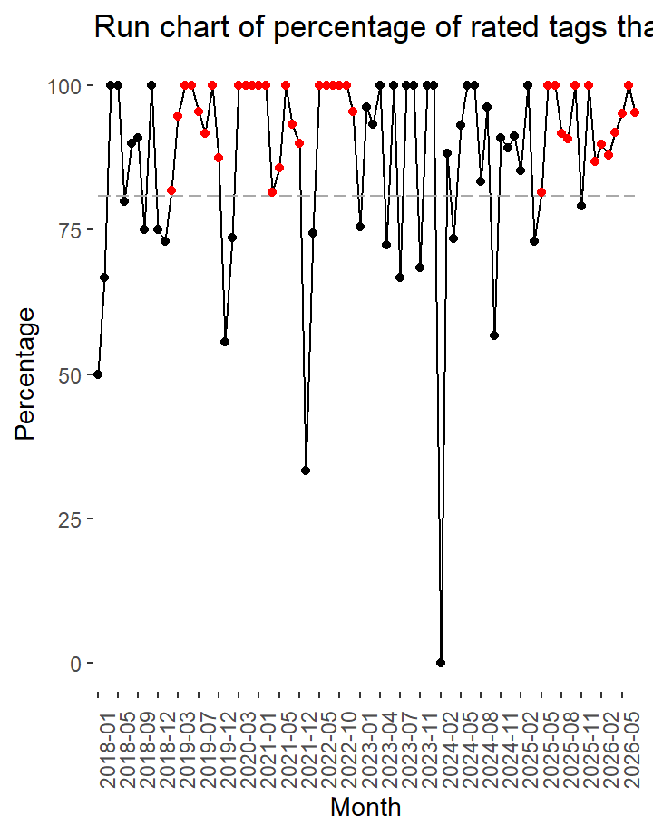

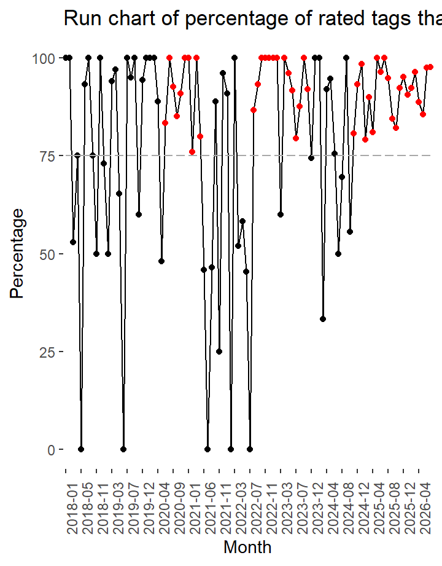

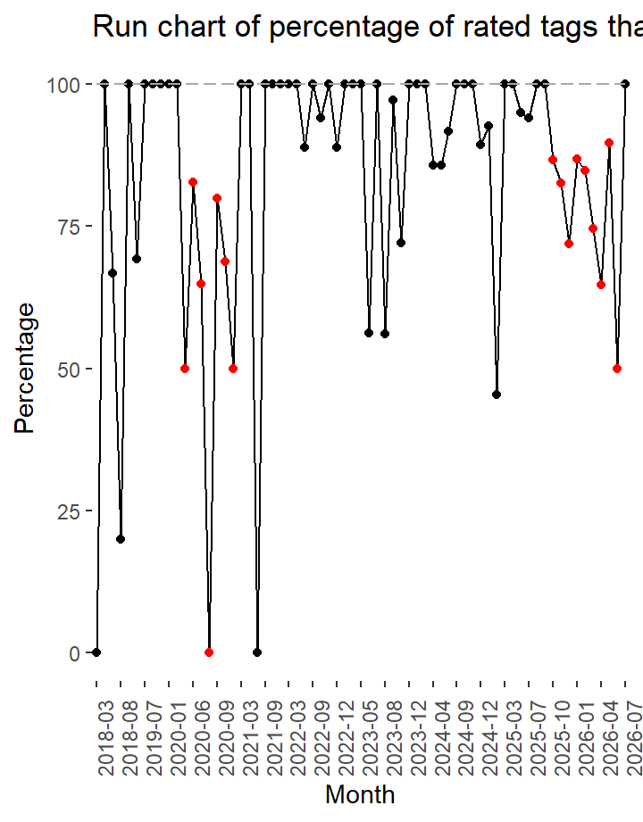

# All stories

### P chart of percentage tags that are positive

[interactive chart not shown]

**Are stories becoming more positive?**

In this chart the percentage of positive tags are plotted for each month. See About for more about tags. By making this a control chart, any changes in the central percentage or unusual variation can be detected. A p chart is the most appropriate chart for percentages and change or variation is detected by looking for these features:

1. A single point outside the (3 sigma) control limits.
2. Eight consecutive points above or below the centreline.
3. Six consecutive points increasing or decreasing.
4. Two out of three consecutuve points in the outer one-third (2 to 3 sigma).
5. Fifteen consecutive points in the inner one third.

The first 20 months are used to calculate the centreline. New centrelines are calculated from where eight consecutive points are above or below the centreline.

### Swarm plot of areas of improvement in critical stories by location from Jul 2025

[interactive chart not shown]

**What are the main issues being raised in stories with some critical feedback?**

Review the issues being highlighted in stories with some critical content. This should make it easy to identify recurring issues being fed-back about one location.

# Surgery

### Are stories becoming more or less positive?

[interactive chart not shown]

### How do you feel? top 30 tags since Jul 2025

[interactive chart not shown]

### What was good? What could be improved? tags since Jul 2025

[interactive chart not shown]

### Stories since Jul 2025

| PostID | Date | Title | What was good? | What could be improved? | How did you feel? |
| --- | --- | --- | --- | --- | --- |
| 1376130 | 2025-07-08 | I had a positive experience | D ok, I was kept informed throughout the procedure, The staff were friendly and made me feel at ease, Friendly, Informed, Staff |  | Releived, Put at ease, Satisfied |
| 1377611 | 2025-07-15 | Treated very well the staff | Communication with patient, Staff, Compassion |  | Treated well |
| 1382259 | 2025-08-05 | Total Hip Replacement as an inpatient | Pathways and continuity, Empathetic, Professionalism and expertise, Compassion, Staff, Theatre team, Systems and processes | Pre-op information, Communication | Informed, Frustrated, In pain |
| 1384728 | 2025-08-16 | Couldn't have asked for a better experience | Infection control, Professional, Anaesthetists, Communication, Dignity & respect, Staff, Friendly, Compassion |  | Looked after, In good hands |
| 1387832 | 2025-08-29 | My daughter's treatment | Theatre team, Air ambulance crew, Staff, Care, Seen quickly, Treatment, Compassion, Dignity & respect, Amazing staff |  | Very relieved, In good hands, Well looked after, Confident in the service |
| 1389880 | 2025-09-08 | Emergency surgery | Treatment, Surgical team, Staff, Care, Support, Information, Dedication, Compassion |  | Hopeful, Thankful, Cared for, Valued, At ease, Well looked after |
| 1389949 | 2025-09-08 | Care after having heart attack | Compassion, Information, Services, Staff, Treatment | Tranfers borders and blocking, Staff availability, Waiting | Frustrated |
| 1391597 | 2025-09-16 | A wonderful team | General, Doctos, Support, Professionalism and expertise, Staff, Care, Care team, Systems and processes, Great team |  | Satisfied, Assured, In awe, Delighted, Supported |
| 1392864 | 2025-09-23 | Impeccable communication and support | Care, Care decisions, Communication, Great team, Communication and information, Treatment, Support |  | Supported, Safe, Listened to |
| 1398547 | 2025-10-19 | My replacement hip operation | Staff, Great team, Nothing too much trouble, Compassion, Infection control, Food, fluid and nutrition |  | Welcomed, Like i mattered, Thankful |

[output cut: 91 more lines]

# Medicine

### Are stories becoming more or less positive?

[interactive chart not shown]

### How do you feel? top 30 tags since Jul 2025

[interactive chart not shown]

### What was good? What could be improved? tags since Jul 2025

[interactive chart not shown]

### Stories since Jul 2025

| PostID | Date | Title | What was good? | What could be improved? | How did you feel? |
| --- | --- | --- | --- | --- | --- |
| 1375439 | 2025-07-04 | Very caring, understanding and highly professional | Compassion, Care, Professional, Staff, Information |  | Put at ease |
| 1376814 | 2025-07-11 | It was outstanding from start to finish | Wonderful, Friendly, Child-friendly, Quick, Explained everything, Smooth process |  | Calm and relaxed, Grateful |
| 1376912 | 2025-07-11 | I had a superb level of care from staff | Professional, Systems and processes, Superb, High level of care, Great team, Staff |  | Grateful, Appreciative |
| 1377207 | 2025-07-14 | Comfortable and well cared for | Upbeat, Smiling, Compassion, Staff |  | Grateful, Safe, Felt seen, Well looked after, Comfortable |
| 1379204 | 2025-07-22 | Quick and efficient process for prostate biopsy | Care, Systems and processes, Quick procedure, Information |  | Reassured, Thank you |
| 1379900 | 2025-07-24 | Stroke recovery | Professionalism and expertise, Mobility, Compassion, Patient, Stroke care |  | Happy, Thanks |
| 1381682 | 2025-08-03 | I was really well looked after | Staff, Communication with patient, Information |  | Well looked after |
| 1383758 | 2025-08-12 | Roxburghe Day Unit Team - Improved Overall Wellbeing | Wellbeing, Kind, Wonderful, Food, fluid and nutrition, Lunch, Inspiring, Thoughtful, Garden, Venue, Staff, Macmillan nurses, Support, Love, Joy, Laughs, Compassion, Gentle, Uplifted mood, Lovely, Comp… |  | Supported, Cared for, Gratitude |
| 1384002 | 2025-08-13 | Absolutely fantastic | Compassion, Staff |  | Thank you |
| 1384118 | 2025-08-13 | Wisdom tooth removal | Responsive, Communication with patient, Staff, Dental care, Reassuring, Seen quickly | Staff availability, Waiting list | Reassured, Safe, Cared for |

[output cut: 137 more lines]

# Maternity

### Are stories becoming more or less positive?

[interactive chart not shown]

### How do you feel? top 30 tags since Jul 2025

[interactive chart not shown]

### What was good? What could be improved? tags since Jul 2025

[interactive chart not shown]

### Stories since Jul 2025

| PostID | Date | Title | What was good? | What could be improved? | How did you feel? |
| --- | --- | --- | --- | --- | --- |
| 1377096 | 2025-07-12 | They made me feel so supported and looked after | Students, Easy to talk to, Phenomenal, Lovely staff, Amazing midwife, High level of care, Environment and facilities, Communication and information | Communication beforehand, Overwhelming | Well informed, Lucky, Put at ease, Comfortable, Supported, Looked after, Happy, Reassured |
| 1379233 | 2025-07-22 | My labour experience | Professionalism and expertise, Care, Personable, Experienced, Systems and processes, Dignity & respect, Open minded staff, Postnatal, Impressive, Environment and facilities, Midwives, Facilities, Comm… |  | Cared for, Relaxed, Safe, Nervous at first, Pain management, Grateful, Supported |
| 1384002 | 2025-08-13 | Absolutely fantastic | Compassion, Staff |  | Thank you |
| 1387258 | 2025-08-27 | Amazing care and attention | Care, Staff, Wonderful |  | Thankful, Happy |
| 1390350 | 2025-09-10 | Amazing service | Staff, Information, Compassion, Communication with patient, Midwives, Empathetic, Great team, Na |  | Supported, Thankful |
| 1396422 | 2025-10-08 | They have all been fantastic | Administrators, Staff, Services, Short waiting time, Amazing, Quick appointment, Anp, Compassion, Mental health professional, Assessment and management, Aftercare |  | Well looked after, Thanks, Lucky, Validated, Listened to |
| 1398539 | 2025-10-19 | Giving birth | Midwives, Staff, Compassion | Temperature, Communication | Upset, Stressed, Scared, Frustrated, Supported, Uncomfortable |
| 1400008 | 2025-10-26 | Amazing care | An asset, Staff, Amazing, Empathetic, Compassion, Kind |  | At ease, Listened to, Cared for |
| 1400451 | 2025-10-28 | Positive maternity care | Staff, Fantastic midwives, A credit, Pleasant experience |  | Lucky, Thankful, Welcomed |
| 1400842 | 2025-10-29 | Emergency C-section and Neonatal Team Care | Communication, Calming, Care, Informed, Can't praise them enough |  | In safe hands, In control, Supported, Informed, Well looked after, Thankful |

[output cut: 46 more lines]

# Emergency

### Are stories becoming more or less positive?

[interactive chart not shown]

### How do you feel? top 30 tags since Jul 2025

[interactive chart not shown]

### What was good? What could be improved? tags since Jul 2025

[interactive chart not shown]

### Stories since Jul 2025

| PostID | Date | Title | What was good? | What could be improved? | How did you feel? |
| --- | --- | --- | --- | --- | --- |
| 1376504 | 2025-07-09 | My mum's treatment | Communication and information, Compassion, Communication with patient, Staff, Information, Professionalism and expertise | Referral, Waiting, Information | Reassured, Alarmed |
| 1384144 | 2025-08-13 | Thank you for the care and kindness | Above and beyond, Staff, Care, Information, Compassion |  | Thanks |
| 1386982 | 2025-08-26 | Blockades and barriers every step of the way | Dignity & respect | Ramp, Services, General, Dignity & respect, Care, Support | Ignored, Unsupported, Worthless, Not cared for, Humiliated, Alone, Unworthy, Disrespected |
| 1387832 | 2025-08-29 | My daughter's treatment | Theatre team, Air ambulance crew, Staff, Care, Seen quickly, Treatment, Compassion, Dignity & respect, Amazing staff |  | Very relieved, In good hands, Well looked after, Confident in the service |
| 1388001 | 2025-08-30 | Nothing has been too much trouble | Pain management, Compassion, Staff, Dignity & respect, Systems and processes, Nothing too much trouble, Great team |  | Grateful, Supported, Well looked after |
| 1389949 | 2025-09-08 | Care after having heart attack | Compassion, Information, Services, Staff, Treatment | Tranfers borders and blocking, Staff availability, Waiting | Frustrated |
| 1390229 | 2025-09-09 | Staff at RACH emergency | Staff, Very good care, Very good service, Exemplary, Fantastic experience, Quick |  | Very grateful |
| 1390780 | 2025-09-11 | A shining example of what real care looks like | Exemplary care, Compassion, Professional, Skillful, Patient, Staff, Amazing, Care, Paediatricians |  | Thankful, Informed, Relieved, Reassured, Comfortable |
| 1394831 | 2025-10-01 | No support for patients | Some nursing staff, Staff | Information, Support, Communication, Pain management, Waiting, Care, Systems and processes | Frustrated |
| 1395628 | 2025-10-04 | The care received was excellent | Staff, Diagnostic tests, Systems and processes, Reassuring, Pain management |  | Reassured, Grateful, Put at ease |

[output cut: 103 more lines]

# Mental Health

### Are stories becoming more or less positive?

[interactive chart not shown]

### How do you feel? top 30 tags since Jul 2025

[interactive chart not shown]

### What was good? What could be improved? tags since Jul 2025

[interactive chart not shown]

### Stories since Jul 2025

| PostID | Date | Title | What was good? | What could be improved? | How did you feel? |
| --- | --- | --- | --- | --- | --- |
| 1414748 | 2026-01-06 | At no point did I feel judged | Trusting, Self-development, Staff, Easy to talk to, Non-judgemental | Access to services | Emotional, Not alone, Supported |
| 1419986 | 2026-01-30 | Understanding, kind, person-centred mental health support | Reassuring, Amazing, Compassion, Calming, Kind, Staff, Communication with patient, Mental health nurse, Quick callback, Cmht, Anp, Self help, Professionalism and expertise, Person centred care, Commun… |  | Calmer, Suicidal, Validated, Relieved, Tired, Struggling, Better, Much better |
| 1427020 | 2026-03-04 | I felt amazing after my sessions | Amazing, Psychologist, Communication with patient |  | Happy |
| 1431544 | 2026-03-25 | Lack of support from staff |  | Attitude, Support, Communication | Dismissed, Upset, Not alone |
| 1400859 | 2025-10-29 | Trying to access care for parents |  | Access to services, Going in circles |  |

# AHP

### Are stories becoming more or less positive?

[interactive chart not shown]

### How do you feel? top 30 tags since Jul 2025

[interactive chart not shown]

### What was good? What could be improved? tags since Jul 2025

[interactive chart not shown]

### Stories since Jul 2025

| PostID | Date | Title | What was good? | What could be improved? | How did you feel? |
| --- | --- | --- | --- | --- | --- |
| 1398777 | 2025-10-20 | Caring and helpful | Friendly, Professional, Systems and processes, Care |  | Impressed, Thankful |
| 1400614 | 2025-10-28 | Grateful to the staff who visit me | Care at home, Amazing, Staff, Amazing staff, Exceptional care, District nursing, Well done, Reassuring |  | Safe, Thank you, Pleased, Praise, Grateful |
| 1402426 | 2025-11-05 | Excellent treatment and support | Staff, Professionalism and expertise, Amazing, Aftercare, Excellent, Care |  | In safe hands, Thankful, Supported |
| 1403654 | 2025-11-11 | The staff have made us feel so welcome and comfortable | Safe enviroment, Engagement, Environment and facilities, Set-up /surroundings, Lovely staff, Communication with patient |  | Comfortable, Proud, Safe, Calm, Thankful, Welcomed |
| 1403873 | 2025-11-11 | You can tell they really care about the children | Services, Speech and language, Fun, Dedicated, Staff, Beneficial, Communication with patient, Engaging, Care | More frequency | Supported |
| 1404744 | 2025-11-14 | Exemplary hospital stay and follow up care | Dedication, Aftercare, Care plan, Care, Staff |  | Thanks, Truly grateful |
| 1407300 | 2025-11-27 | They are amazing people and do a fantastic job | Easy to use, Supportive, Amazing, Teaching, Compassion, Staff, Care, Great team, Care plan, Communication with patient |  | Confident, Supported, In safe hands, Thank you, Very thankful, Blessed, Informed |
| 1411365 | 2025-12-16 | The staff that cared for my Father were first class | Quick response, Wonderful, First class, Staff, Wonderful care, Excellent, Thorough |  | Appreciative, Thankful, Welcomed |
| 1413186 | 2025-12-23 | Podiatrists at Wallace Town | Laughter, Communication, Professionalism and expertise, Careful, Care, Thorough, Jokes |  | Thanks |
| 1433264 | 2026-04-02 | Fractured my back | Care, Support, Staff |  | Thank you |

[output cut: 4 more lines]

# About

#### **What are Care Opinion Storyboards?**

Care Opinion Storyboards summarise the experiences of people using health and care services shared on [Care Opinion](https://www.careopinion.org.uk). They are primarily intended to help NHS organisations understand the experience of service users including the main themes and how experience changes over time. Storyboards are produced by Healthcare Improvement Scotland with support of Care Opinion and under the Creative Commons licence for non-commercial re-use.

#### **How is feedback summarised?**

Every person who tells their story on Care Opinion is asked to create tags in response to three questions:

1. What was good?
2. What could be improved?
3. How did you feel?

Each tag can be given a negative or positive polarity. If the storyteller chooses not to tag their story moderators may add tags. Tag information about the services used are also recorded with each story and used in this analysis.

Storyboards use a range of charts and visualisations to summarise the tag information.

#### **Where can I find out more?**

If you would like to know more please contact the Healthcare Improvment Scotland Data, Measurement and Business Intelligence team at hcis.DMBI-TEAM@nhs.scot.

[figure not shown]

[figure not shown]